# Into the Tidyverse

Session Five Exercises

Remember, before you can use the tidyverse, you need to load the package.

```r
library(tidyverse)
```

## Missing Pieces

### R Scripts

1. Create an R Script that will produce a histogram of the city mileages in the `mpg` dataset
2. Run this script
3. Why is it important to include library imports at the start of our R scripts?
4. Create an R Script containing a pipeline that takes the `diamonds` dataset, groups by `color`, and summarises the mean of each group
5. Leave a blank line and then add code to create a bar chart of the classes in `mpg`
6. Place your cursor on the first line of the script. What happens when you use `ctrl-enter`? What code is executed? Where does your cursor move to?

## Advanced Data Visualisation

### Statistical Transformations

1. In our proportional bar chart we had to write `group = -1`. Why was that needed and what would happen without it?

```r
ggplot(data = diamonds) +
  geom_bar(mapping = aes(x = cut, y = ..prop.., group = -1))
```

2. What are the default stats for `geom_line()`, `geom_histogram()`, and `geom_density()`?
3. What variables does `stat_smooth()` compute? What parameters control its behaviour?

### Positional Adjustments

1. Create a jitter plot both by using `geom_point()` with `position = "jitter"` and `geom_jitter() with the diamonds dataset
2. What parameters can be used to control the behaviour of `geom_jitter()`? Instead of using `position = "jitter"`, use `position = position_jitter(...)` and confirm that you can pass in these same parameters
3. Compare and contrast the use of `geom_jitter()` and `geom_count()` in plotting `hwy` against `cty` with the `mpg` dataset

### Coordinate Systems

1. Create a bar plot of the cylinder numbers in the `mpg` dataset and convert it into a Coxcomb plot using `coord_polar()`
2. What does the plot below tell you about the relationship between city and highway mileage in the `mpg` dataset? Why is `coord_fixed()` important and what does `geom_abline()` do?

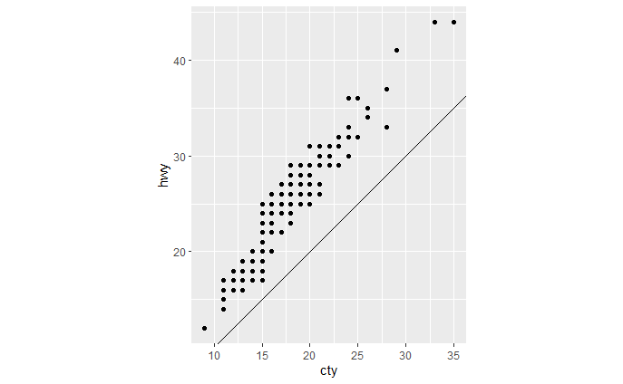

```r
ggplot(data = mpg, mapping = aes(x = cty, y = hwy)) +
  geom_point() +
  geom_abline() +
  coord_fixed()
```

### Theming

1. Create a plot of your choice and use the `theme()` function to make the gridlines green
2. How can we use theming to improve the look of the pie chart we generated earlier?

### Further Research

1. Look at the latest ggplot cheatsheet [here](https://rstudio.com/wp-content/uploads/2016/11/ggplot2-cheatsheet-2.1.pdf). What geometries have we not mentioned?
2. Read the section titled ‘Statistical transformations’ from Chapter 3 of [R4DS](https://r4ds.had.co.nz/data-visualisation.html). This goes into more detail regarding the interplay between stats and geometries. Try creating a bar chart using `stat_count()`
3. Look at the help page for `coord_cartesian()`. How can we use this to zoom in on our plot
4. Read [this](http://www.sthda.com/english/wiki/ggplot2-axis-scales-and-transformations) guide on axis scale and transformations in ggplot. In particular, have a look at the `scale_*_date()` family of functions
5. Read [this](https://ggplot2.tidyverse.org/reference/labeller.html) page of the ggplot documentation, showing how to setup custom facet labels